# 13_compare_mean_median

## 13_compare_mean_median

#### Question

1. Depending on the type of distribution, we can make a strong claim regarding the mean and median.
   - Symmetric (bell, uniform, bimodal)
     - $\text{mean} \approx \text{median}$
   - Skew-right
     - $\text{mean} > \text{median}$
   - Skew-left
     - $\text{mean} < \text{median}$

   A sample was gathered and visualized with a histogram.

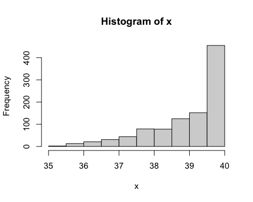

   What claim can you make regarding the mean and median?
   1. $\text{mean} \approx \text{median}$
   2. $\text{mean} > \text{median}$
   3. $\text{mean} < \text{median}$

#### Solution

#### Question

2. Depending on the type of distribution, we can make a strong claim regarding the mean and median.
   - Symmetric (bell, uniform, bimodal)
     - $\text{mean} \approx \text{median}$
   - Skew-right
     - $\text{mean} > \text{median}$
   - Skew-left
     - $\text{mean} < \text{median}$

   A sample was gathered and visualized with a histogram.

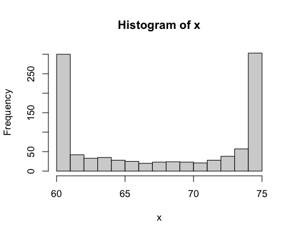

   What claim can you make regarding the mean and median?
   1. $\text{mean} \approx \text{median}$
   2. $\text{mean} > \text{median}$
   3. $\text{mean} < \text{median}$

#### Solution

#### Question

3. Depending on the type of distribution, we can make a strong claim regarding the mean and median.
   - Symmetric (bell, uniform, bimodal)
     - $\text{mean} \approx \text{median}$
   - Skew-right
     - $\text{mean} > \text{median}$
   - Skew-left
     - $\text{mean} < \text{median}$

   A sample was gathered and visualized with a histogram.

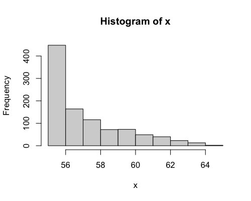

   What claim can you make regarding the mean and median?
   1. $\text{mean} \approx \text{median}$
   2. $\text{mean} > \text{median}$
   3. $\text{mean} < \text{median}$

#### Solution

#### Question

4. Depending on the type of distribution, we can make a strong claim regarding the mean and median.
   - Symmetric (bell, uniform, bimodal)
     - $\text{mean} \approx \text{median}$
   - Skew-right
     - $\text{mean} > \text{median}$
   - Skew-left
     - $\text{mean} < \text{median}$

   A sample was gathered and visualized with a histogram.

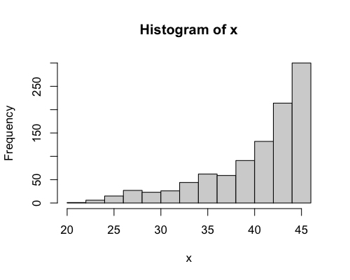

   What claim can you make regarding the mean and median?
   1. $\text{mean} \approx \text{median}$
   2. $\text{mean} > \text{median}$
   3. $\text{mean} < \text{median}$

#### Solution

#### Question

5. Depending on the type of distribution, we can make a strong claim regarding the mean and median.
   - Symmetric (bell, uniform, bimodal)
     - $\text{mean} \approx \text{median}$
   - Skew-right
     - $\text{mean} > \text{median}$
   - Skew-left
     - $\text{mean} < \text{median}$

   A sample was gathered and visualized with a histogram.

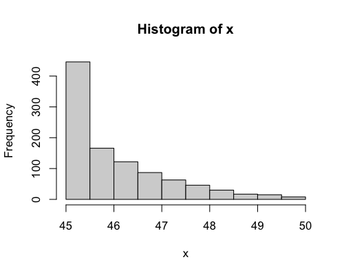

   What claim can you make regarding the mean and median?
   1. $\text{mean} \approx \text{median}$
   2. $\text{mean} > \text{median}$
   3. $\text{mean} < \text{median}$

#### Solution

#### Question

6. Depending on the type of distribution, we can make a strong claim regarding the mean and median.
   - Symmetric (bell, uniform, bimodal)
     - $\text{mean} \approx \text{median}$
   - Skew-right
     - $\text{mean} > \text{median}$
   - Skew-left
     - $\text{mean} < \text{median}$

   A sample was gathered and visualized with a histogram.

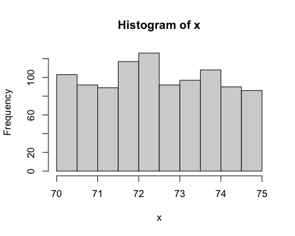

   What claim can you make regarding the mean and median?
   1. $\text{mean} \approx \text{median}$
   2. $\text{mean} > \text{median}$
   3. $\text{mean} < \text{median}$

#### Solution

#### Question

7. Depending on the type of distribution, we can make a strong claim regarding the mean and median.
   - Symmetric (bell, uniform, bimodal)
     - $\text{mean} \approx \text{median}$
   - Skew-right
     - $\text{mean} > \text{median}$
   - Skew-left
     - $\text{mean} < \text{median}$

   A sample was gathered and visualized with a histogram.

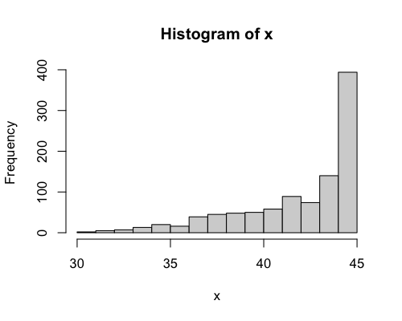

   What claim can you make regarding the mean and median?
   1. $\text{mean} \approx \text{median}$
   2. $\text{mean} > \text{median}$
   3. $\text{mean} < \text{median}$

#### Solution

#### Question

8. Depending on the type of distribution, we can make a strong claim regarding the mean and median.
   - Symmetric (bell, uniform, bimodal)
     - $\text{mean} \approx \text{median}$
   - Skew-right
     - $\text{mean} > \text{median}$
   - Skew-left
     - $\text{mean} < \text{median}$

   A sample was gathered and visualized with a histogram.

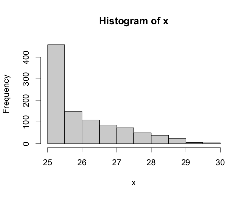

   What claim can you make regarding the mean and median?
   1. $\text{mean} \approx \text{median}$
   2. $\text{mean} > \text{median}$
   3. $\text{mean} < \text{median}$

#### Solution